# Practical Machine Learning Week 4 Course Project

Arshad

10/23/2020

## Introduction

Using devices such as Jawbone Up, Nike FuelBand, and Fitbit it is now possible to collect a large amount of data about personal activity relatively inexpensively. These type of devices are part of the quantified self movement - a group of enthusiasts who take measurements about themselves regularly to improve their health, to find patterns in their behavior, or because they are tech geeks. One thing that people regularly do is quantify how much of a particular activity they do, but they rarely quantify how well they do it. In this project, our goal will be to use data from accelerometers on the belt, forearm, arm, and dumbell of 6 participants. They were asked to perform barbell lifts correctly and incorrectly in 5 different ways. More information is available from the website here: http://web.archive.org/web/20161224072740/http:/groupware.les.inf.puc-rio.br/har

## Data Sources

The training data for this project are available here:

https://d396qusza40orc.cloudfront.net/predmachlearn/pml-training.csv

The test data are available here:

https://d396qusza40orc.cloudfront.net/predmachlearn/pml-testing.csv

The data for this project come from this source: http://web.archive.org/web/20161224072740/http:/groupware.les.inf.puc-rio.br/har.

```r
##Loading the required libraries
library(knitr)
library(caret)
```

```r
library(rpart)
library(rpart.plot)
library(rattle)
library(randomForest)
library(RColorBrewer)

library(gbm)
```

## Loading the Datasets

The data was downloaded directly from the internet and loaded into training_url and testing_url.The training data set had 19622 records, testing data set had 20 records and there were 160 variables.

```r
training_url<- "https://d396qusza40orc.cloudfront.net/predmachlearn/pml-training.csv"
testing_url<- "https://d396qusza40orc.cloudfront.net/predmachlearn/pml-testing.csv"
training_data<- read.csv(url(training_url))
testing_data<- read.csv(url(testing_url))
dim(training_data)
```

```
## [1] 19622   160
```

```r
dim(testing_data)
```

```
## [1]  20 160
```

## Cleansing the data

```r
###Removing variables which had Nearly zero variance.
nzv <- nearZeroVar(training_data)

train_data <- training_data[,-nzv]
test_data <- testing_data[,-nzv]

dim(train_data)
```

```
## [1] 19622   100
```

```r
dim(test_data)
```

```
## [1]  20 100
```

```r
###Removing variables which had NA values
na_val_col <- sapply(train_data, function(x) mean(is.na(x))) > 0.95
train_data <- train_data[,na_val_col == FALSE]
test_data <- test_data[,na_val_col == FALSE]

dim(train_data)
```

```
## [1] 19622    59
```

```r
dim(test_data)
```

```
## [1] 20 59
```

```r
###Removing the first 7 Variables which had non-numeric values and don't contribute to our model.
train_data<- train_data[, 8:59]
test_data<- test_data[, 8:59]
dim(train_data)
```

```
## [1] 19622    52
```

```r
dim(test_data)
```

```
## [1] 20 52
```

## Partitioning the data

As recommended in the course the training data in train_data was divided into two parts.One part of the data is training which consists 60% of the total data and the other part is testing which contains 40% of the total data.

```r
inTrain<- createDataPartition(train_data$classe, p=0.6, list=FALSE)
inTrain<- createDataPartition(train_data$classe, p=0.6, list=FALSE)
training<- train_data[inTrain,]
testing<- train_data[-inTrain,]
dim(training)
```

```
## [1] 11776    52
```

```r
dim(testing)
```

```
## [1] 7846   52
```

## Decision Tree Model & Prediction

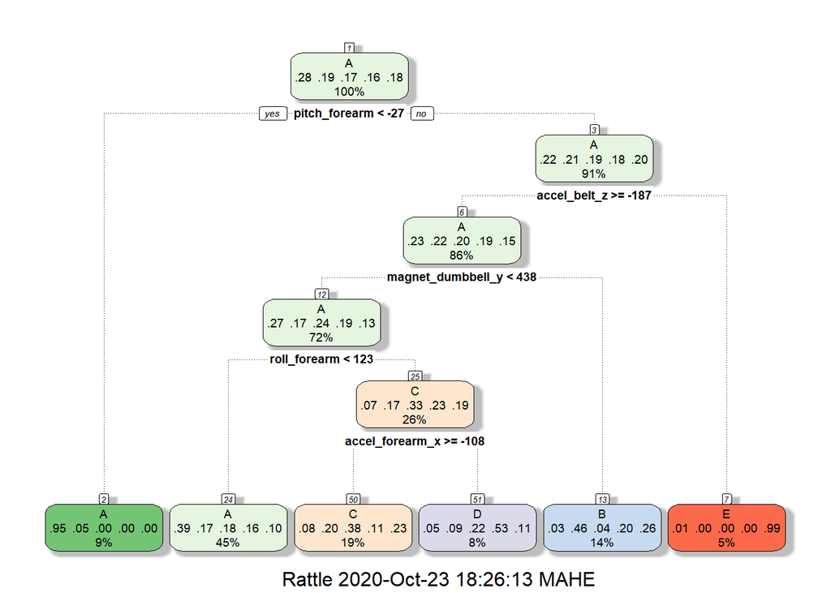

```r
###Fitting data in the model and plotting
library(rattle)
DT_model<- train(classe ~. , data=training, method= "rpart")
fancyRpartPlot(DT_model$finalModel)
```

```r
###Prediction
set.seed(21243)
DT_prediction<- predict(DT_model, testing)
confusionMatrix(DT_prediction, testing$classe)
```

```
## Confusion Matrix and Statistics
##
##           Reference
## Prediction    A    B    C    D    E
##          A 2044  646  627  568  340
##          B   29  499   39  240  288
##          C  116  328  564  173  345
##          D   42   44  138  305   61
##          E    1    1    0    0  408
##
## Overall Statistics
##
##                Accuracy : 0.4869
##                  95% CI : (0.4758, 0.498)
##     No Information Rate : 0.2845
##     P-Value [Acc > NIR] : < 2.2e-16
##
##                   Kappa : 0.3283
##
##  Mcnemar's Test P-Value : < 2.2e-16
##
## Statistics by Class:
##
##                      Class: A Class: B Class: C Class: D Class: E
## Sensitivity            0.9158   0.3287  0.41228  0.23717  0.28294
## Specificity            0.6115   0.9058  0.85150  0.95655  0.99969
## Pos Pred Value         0.4838   0.4557  0.36959  0.51695  0.99512
## Neg Pred Value         0.9481   0.8491  0.87278  0.86480  0.86095
## Prevalence             0.2845   0.1935  0.17436  0.16391  0.18379
## Detection Rate         0.2605   0.0636  0.07188  0.03887  0.05200
## Detection Prevalence   0.5385   0.1396  0.19449  0.07520  0.05226
## Balanced Accuracy      0.7636   0.6173  0.63189  0.59686  0.64131
```

## Gradient Boosting Model and Prediction

```r
set.seed(25621)
gbm_model<- train(classe~., data=training, method="gbm", verbose= FALSE)
gbm_model$finalmodel
```

```r
###Prediction
gbm_prediction<- predict(gbm_model, testing)
gbm_cm<-confusionMatrix(gbm_prediction, testing$classe)
gbm_cm
```

```
## Confusion Matrix and Statistics
##
##           Reference
## Prediction    A    B    C    D    E
##          A 2191   45    0    3    4
##          B   25 1401   34    7   17
##          C   12   66 1319   58   15
##          D    3    2   15 1206   19
##          E    1    4    0   12 1387
##
## Overall Statistics
##
##                Accuracy : 0.9564
##                  95% CI : (0.9517, 0.9608)
##     No Information Rate : 0.2845
##     P-Value [Acc > NIR] : < 2.2e-16
##
##                   Kappa : 0.9449
##
##  Mcnemar's Test P-Value : 1.63e-13
##
## Statistics by Class:
##
##                      Class: A Class: B Class: C Class: D Class: E
## Sensitivity            0.9816   0.9229   0.9642   0.9378   0.9619
## Specificity            0.9907   0.9869   0.9767   0.9941   0.9973
## Pos Pred Value         0.9768   0.9441   0.8973   0.9687   0.9879
## Neg Pred Value         0.9927   0.9816   0.9923   0.9879   0.9915
## Prevalence             0.2845   0.1935   0.1744   0.1639   0.1838
## Detection Rate         0.2793   0.1786   0.1681   0.1537   0.1768
## Detection Prevalence   0.2859   0.1891   0.1874   0.1587   0.1789
## Balanced Accuracy      0.9862   0.9549   0.9704   0.9659   0.9796
```

From the Gradient Boosting Model we got the prediction accuracy of 96% which was in the satisafctory level.

## Random Forest Model and Prediction

```r
set.seed(26817)
###Fitting data in the model
RF_model<- train(classe ~. , data=training, method= "rf", ntree=100)
###Prediction
RF_prediction<- predict(RF_model, testing)
RF_cm<-confusionMatrix(RF_prediction, testing$classe)
RF_cm
```

```
## Confusion Matrix and Statistics
##
##           Reference
## Prediction    A    B    C    D    E
##          A 2230    7    0    0    0
##          B    0 1497    8    0    0
##          C    1   12 1358   26    5
##          D    0    1    2 1259    5
##          E    1    1    0    1 1432
##
## Overall Statistics
##
##                Accuracy : 0.9911
##                  95% CI : (0.9887, 0.993)
##     No Information Rate : 0.2845
##     P-Value [Acc > NIR] : < 2.2e-16
##
##                   Kappa : 0.9887
##
##  Mcnemar's Test P-Value : NA
##
## Statistics by Class:
##
##                      Class: A Class: B Class: C Class: D Class: E
## Sensitivity            0.9991   0.9862   0.9927   0.9790   0.9931
## Specificity            0.9988   0.9987   0.9932   0.9988   0.9995
## Pos Pred Value         0.9969   0.9947   0.9686   0.9937   0.9979
## Neg Pred Value         0.9996   0.9967   0.9984   0.9959   0.9984
## Prevalence             0.2845   0.1935   0.1744   0.1639   0.1838
## Detection Rate         0.2842   0.1908   0.1731   0.1605   0.1825
## Detection Prevalence   0.2851   0.1918   0.1787   0.1615   0.1829
## Balanced Accuracy      0.9989   0.9925   0.9929   0.9889   0.9963
```

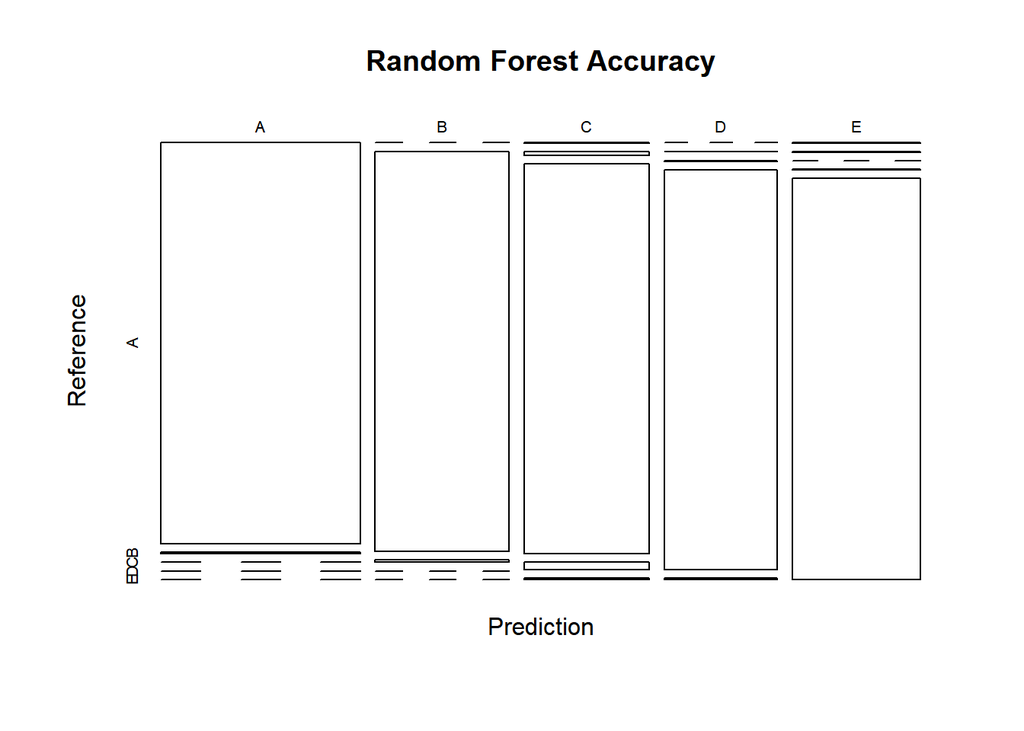

```r
###plot
plot(RF_cm$table, col=RF_cm$byClass, main="Random Forest Accuracy")
```

From the Random Forest Model we got the prediction accuracy of 99% which was close to perfect accuracy level.

## To reach a conclusion we need to see how each model has predicted the validation dataset across the classifications. The Decision Tree model was not considered as it didn’t reach the satisfactory prediction accuracy level, so only Random Forest and Gradient Boosting models are being compared to see which is more accurate.

```r
RF_cm$overall
```

```
##       Accuracy          Kappa  AccuracyLower  AccuracyUpper   AccuracyNull
##      0.9910783      0.9887144      0.9887412      0.9930386      0.2844762
## AccuracyPValue  McnemarPValue
##      0.0000000            NaN
```

```r
gbm_cm$overall
```

```
##       Accuracy          Kappa  AccuracyLower  AccuracyUpper   AccuracyNull
##   9.564109e-01   9.448601e-01   9.516567e-01   9.608222e-01   2.844762e-01
## AccuracyPValue  McnemarPValue
##   0.000000e+00   1.629660e-13
```

## Conclusion

After going throught the overall statistics data, we can conclude that the Random Forest is more accurate than GBM. Hence we will be selecting Random Forest model for final prediction from test_data .

## Final Prediction using Random Forest model on the testing data

```r
prediction_test<- predict(RF_model, test_data)
prediction_test
```

```
##  [1] B A B A A E D B A A B C B A E E A B B B
## Levels: A B C D E
```